# Logistic Regression

Albert Y. Kim

Last updated on 2020-02-26

# Data

Read in training data from Kaggle’s [Give Me Some Credit](https://www.kaggle.com/c/GiveMeSomeCredit/). Note that we are going to revisit such ideas when we have our “ethics in machine learning” module.

```r
library(tidyverse)
library(broom)

financial_distress_orig <-
  "https://rudeboybert.github.io/SDS293/static/methods/logisitic/cs-training.csv" %>%
  read_csv() %>%
  select(ID = X1, in_financial_distress = SeriousDlqin2yrs, age)
```

Let’s deliberately tinker and engineer this data for our exploration of logistic regression: For those individuals who are in financial distress, let’s add an offset of 50 to their ages. You’ll see why later.

```r
offset <- 50
financial_distress <- financial_distress_orig %>%
  mutate(age = ifelse(in_financial_distress == 1, age + offset, age))
```

Now randomly split data into `train` and `test` so that we can fit to train and predict on test. Note that this corresponds to the “validation set” approach that is used mostly for illustrative purposes and not used in practice as using this approach you wouldn’t be making predictions on every observation. Be sure to `View()` these data frames after you create them:

```r
set.seed(76)
cs_training <- financial_distress %>%
  sample_frac(0.25)
cs_test <- financial_distress %>%
  anti_join(cs_training, by="ID")
```

# Exploratory Data Analysis

We engineered the two boxplots to not overlap by adding the `offset` strictly for purposes of this educational exercise.

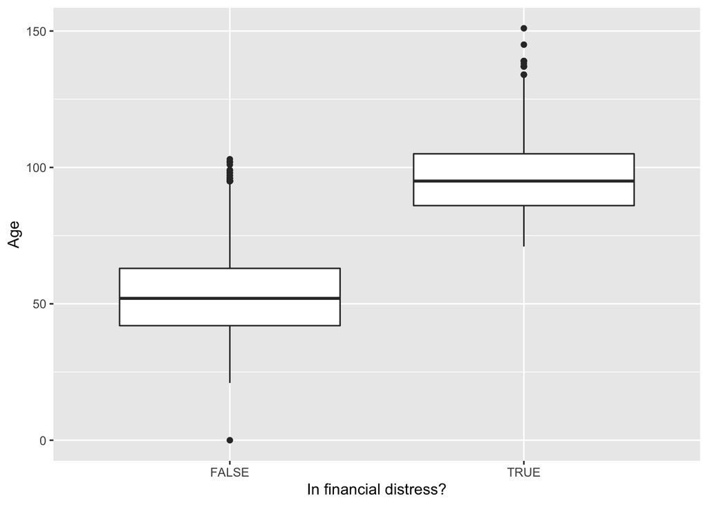

```r
ggplot(cs_training, aes(x = as.logical(in_financial_distress), y = age)) +
  geom_boxplot() +
  labs(x = "In financial distress?", y = "Age")
```

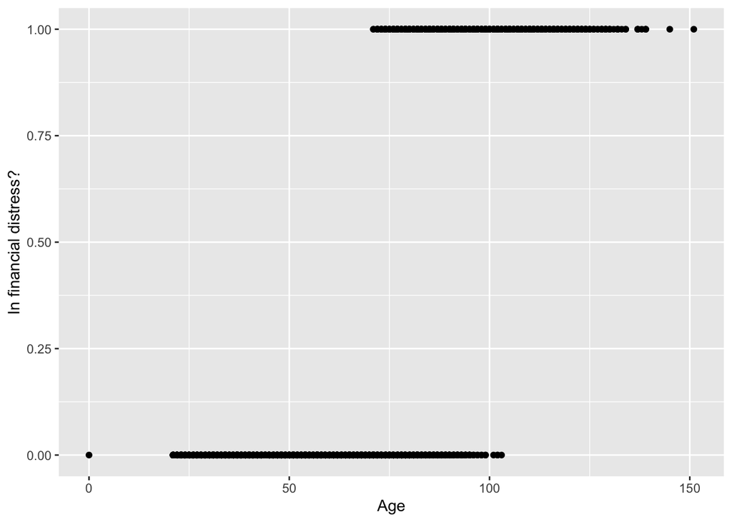

```r
# Let's create a scatterplot but with age on the x-axis. Note this plot suffers
# from overplotting:
ggplot(cs_training, aes(x = age, y = in_financial_distress)) +
  geom_point() +
  labs(x = "Age", y = "In financial distress?")
```

Let’s “jitter” the plot a little to break up the overplotting. In other words, add random vertical “nudges” to the points so that we can get a sense of how many plots are on top of each other. Note this is only a visualization tool; it does not alter the original values in the data frame. For more info on `geom_jitter()` read [ModernDive](https://moderndive.com/2-viz.html#overplotting)

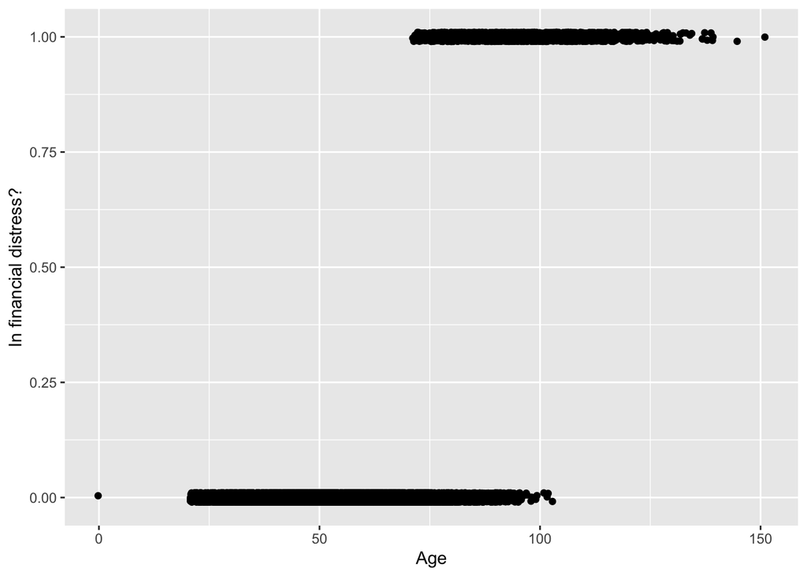

```r
ggplot(cs_training, aes(x = age, y = in_financial_distress)) +
  geom_jitter(height = 0.01) +
  labs(x = "Age", y = "In financial distress?")
```

The best fitting linear regression line in blue is no good in this particular case; you end up with fitted probabilities less than 0.

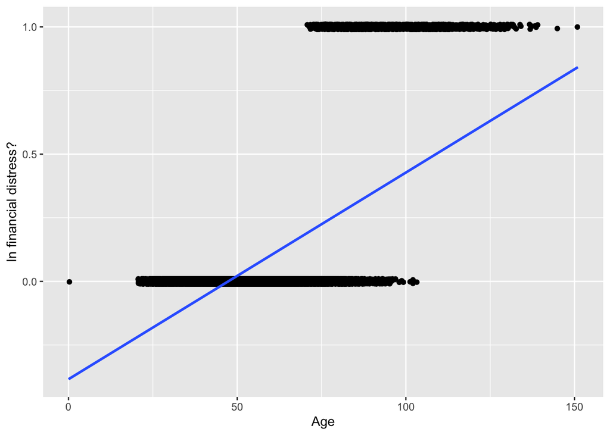

```r
ggplot(cs_training, aes(x = age, y = in_financial_distress)) +
  geom_jitter(height = 0.01) +
  labs(x = "Age", y = "In financial distress?") +
  geom_smooth(method = "lm", se = FALSE)
```

# Fit/train model

```r
# Fit a logistic regression model. Note the use of glm() instead of lm()
model_logistic <- glm(in_financial_distress ~ age, family = "binomial", data = cs_training)

# 2.a) Extract regression table with confidence intervals
# Notice coefficient for age. Is it positive or negative?
model_logistic %>%
  broom::tidy(conf.int = TRUE)
```

| term | estimate | std.error | statistic | p.value | conf.low | conf.high |
| --- | --- | --- | --- | --- | --- | --- |
| (Intercept) | -21.0416040 | 0.3970942 | -52.98895 | 0 | -21.8358197 | -20.2788869 |
| age | 0.2418958 | 0.0047613 | 50.80454 | 0 | 0.2327442 | 0.2514123 |

```r
# 2.b) Extract point-by-point info of points used to fit model. Be sure to
# View() this data frame
fitted_points_logistic <- model_logistic %>%
  broom::augment()

# The .fitted values are the fitted log-odds however, NOT fitted probabilities.
# We convert to fitted probabilities using inverse-logit function. Be sure to
# View() this data frame
fitted_points_logistic <- fitted_points_logistic %>%
  mutate(fitted_prob = 1/(1 + exp(-.fitted)))

# 2.c) Extract model summary info
model_logistic %>%
  broom::glance()
```

| null.deviance | df.null | logLik | AIC | BIC | deviance | df.residual |
| --- | --- | --- | --- | --- | --- | --- |
| 18417.22 | 37499 | -2433.432 | 4870.865 | 4887.929 | 4866.865 | 37498 |

# Make predictions

Make predictions on test data. Compare this to use of `broom::augment()` for `fitted_points_logistic`

```r
predicted_points_logistic <- model_logistic %>%
  broom::augment(newdata = cs_test)
```

# Visualize fitted model

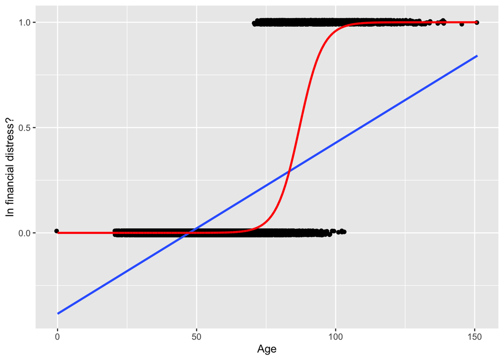

```r
ggplot(data = fitted_points_logistic, aes(x = age, y = in_financial_distress)) +
  # Training data with black points:
  geom_jitter(height = 0.01) +
  # Best fitting linear regression line in blue:
  geom_smooth(method = "lm", se = FALSE) +
  # Best fitting logistic curve in red:
  geom_line(data = fitted_points_logistic, mapping = aes(y = fitted_prob), col = "red", size = 1) +
  labs(x = "Age", y = "In financial distress?")
```

# Exercise